# Alice Resultados

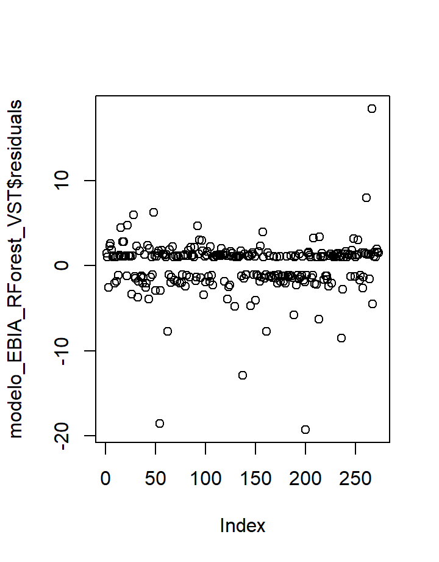

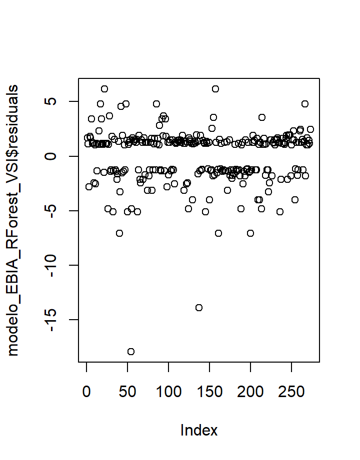

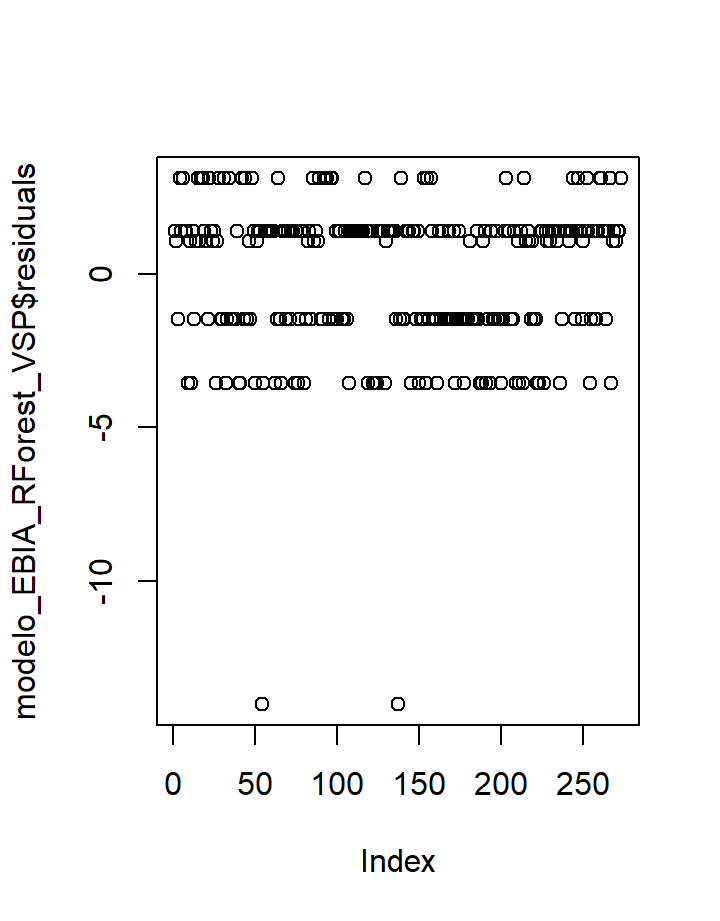

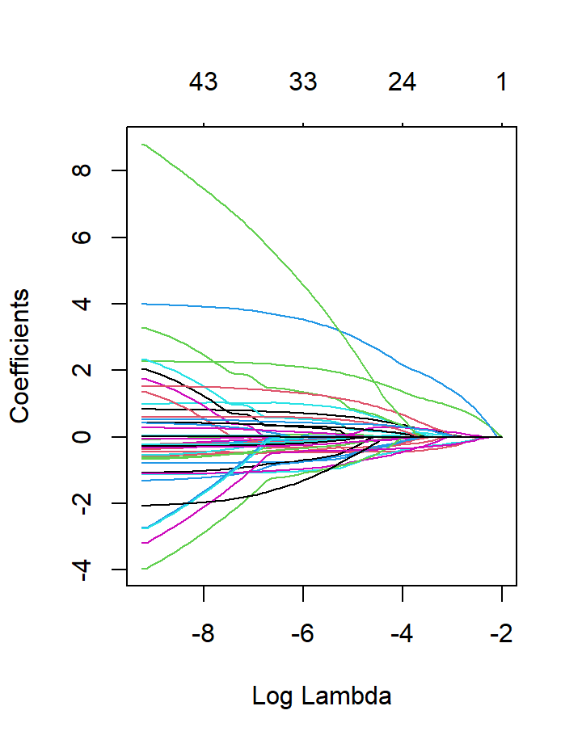

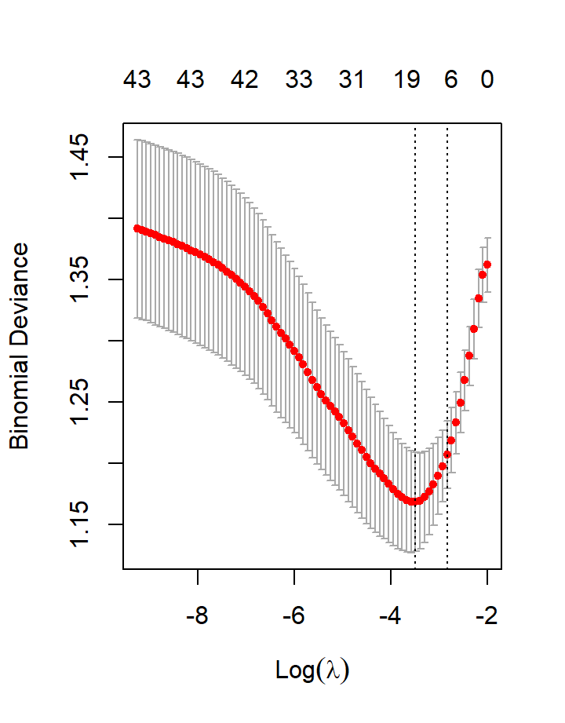

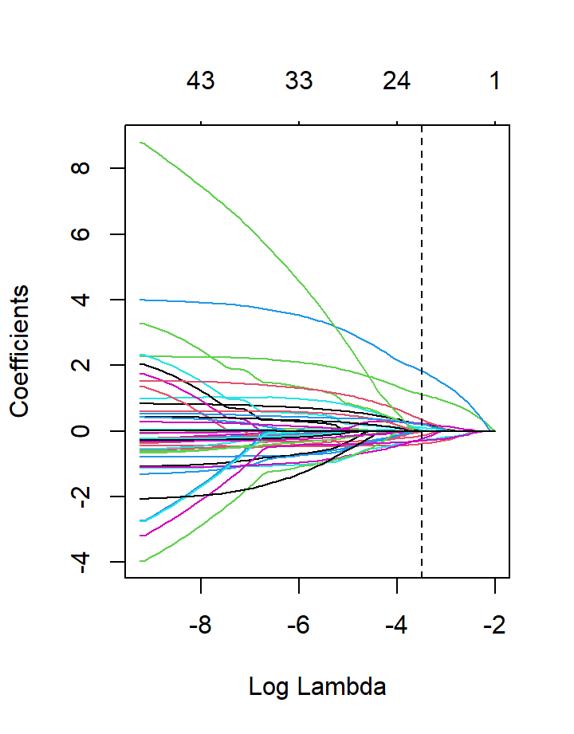

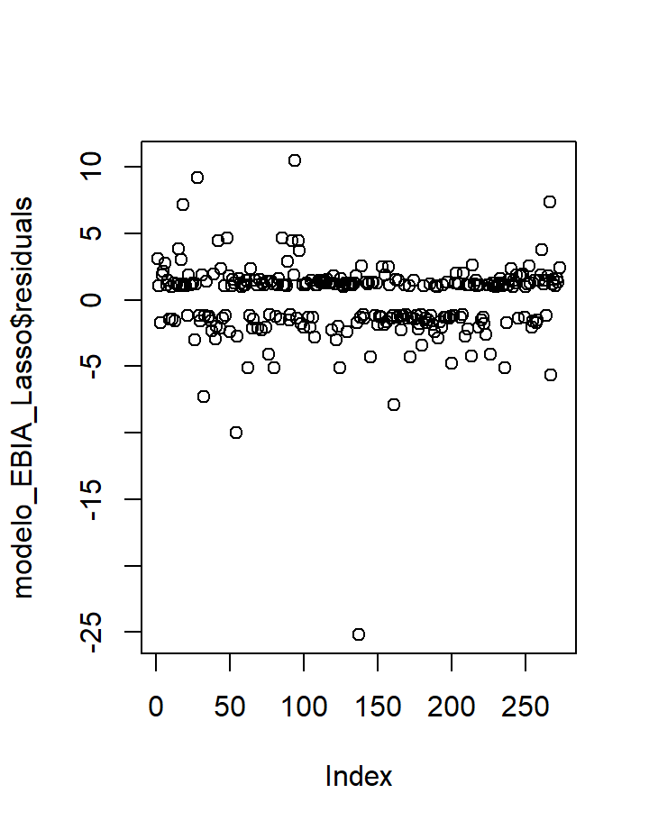

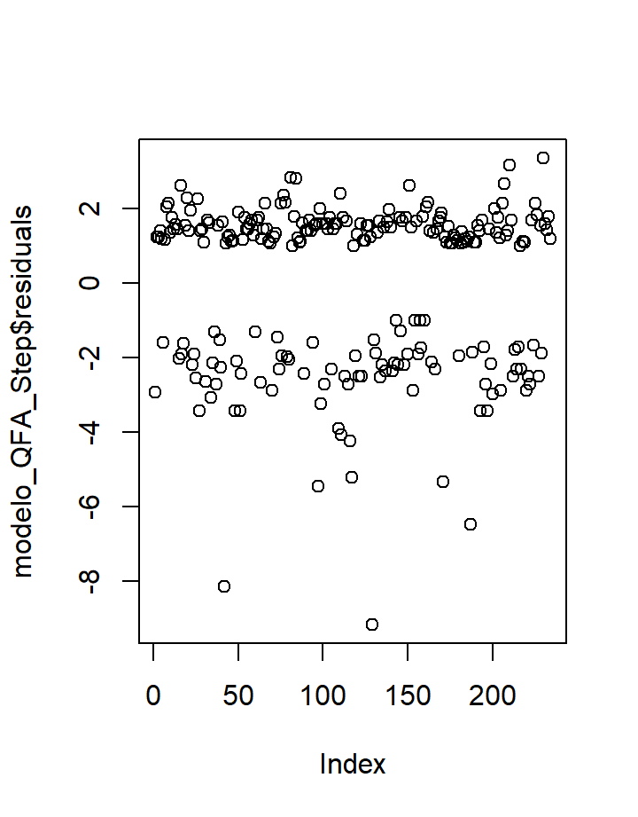

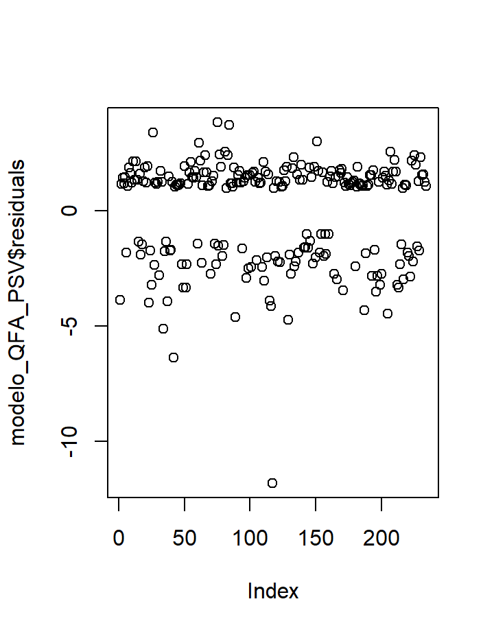

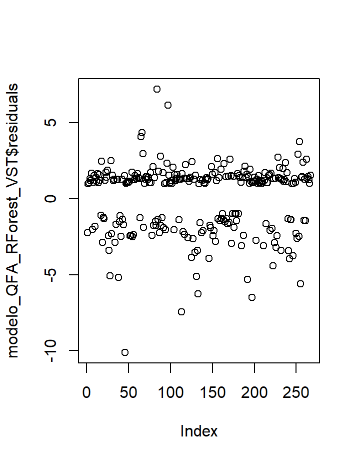

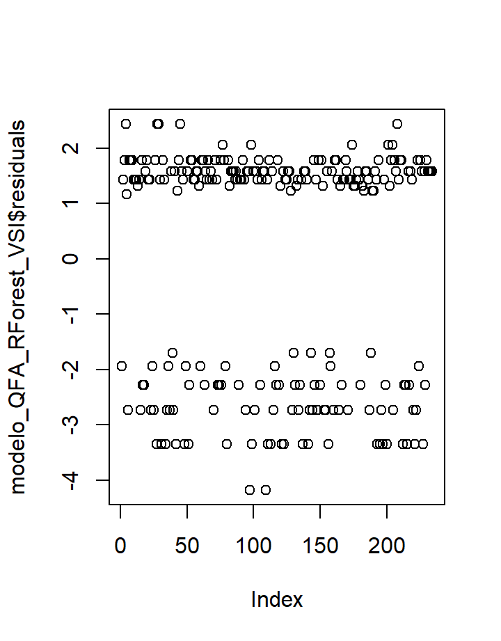

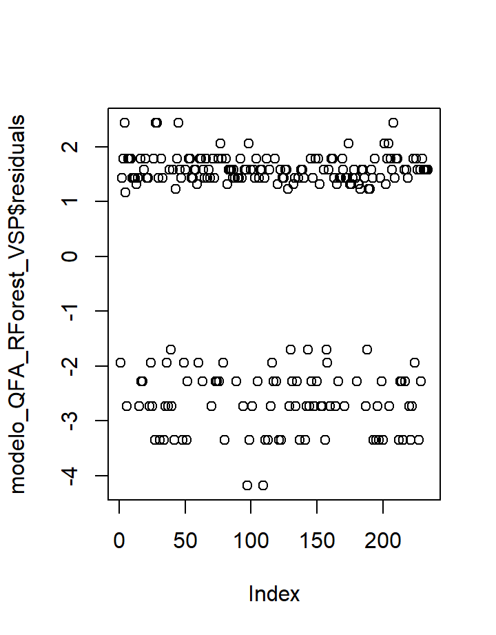

[5 more figures not shown]

# Pacotes e Diretório

**1. Pacotes e Diretório**

```r
# Pacotes Necessarios -----------------------------------------------------
  library(VSURF)
  library(glmnet)
  library(plotmo)
  library(lmtest)
  library(dplyr)
  library(VSURF)
  library(tidyverse)
  library(corrplot)
  library(rpart)
  library(rpart.plot)
  library(hnp)

  # Pacotes Random Forest
  #library(cforest) #versão falhou
  library(party)
  library(randomForest)
  library(tree)
  library(reprtree)

  # Pacote Porpuseful
  library(purposeful)


# Importando dados (da Paula) ---------------------------------------------

setwd("C:/Users/User/Dropbox/Mestrado em Estatística e Experimentação Agropecuária/Dissertaçao/V2")
dados <- read.csv("EBIA.csv", sep = ";", header = TRUE)
#dados <- read.csv("QFA.csv", sep = ";", header = TRUE)

  dados$X1 <- as.factor(dados$X1)
  dados$X2 <- as.factor(dados$X2)
  dados$X3 <- as.factor(dados$X3)
  dados$X4 <- as.factor(dados$X4)
  dados$X5 <- as.factor(dados$X5)
  dados$X6 <- as.factor(dados$X6)
  dados$X7 <- as.factor(dados$X7)
  dados$X8 <- as.factor(dados$X8)
  dados$X9 <- as.factor(dados$X9)
  dados$X10 <- as.factor(dados$X10)
  dados$X11 <- as.factor(dados$X11)
  dados$X12 <- as.factor(dados$X12)
  dados$X22 <- as.factor(dados$X22)
  dados$X31 <- as.factor(dados$X31)
  dados$X32 <- as.factor(dados$X32)
  dados$X33 <- as.factor(dados$X33)
  dados$X37 <- as.factor(dados$X37)
  dados$X38 <- as.numeric(dados$X38)
  dados$X49.bin <- as.factor(dados$X49.bin)

dd <- dados[,c(1,2,3,4,5,6,7,8,9,10,11,12,22,28,29,34,35,45)]
dr <- subset(dd, !is.na(dd$X49.bin)) # retirando os na da variável resposta
dr <- na.exclude(dr)
dt <- dr
```

# Dicionário dos dados

**2. Dicionário dos dados**

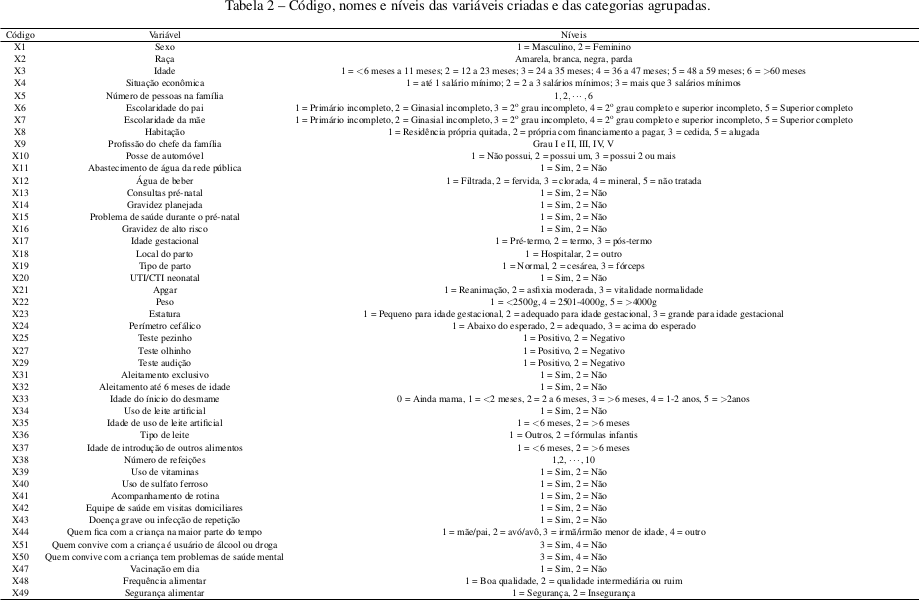

# Fluxograma

**1. Fluxograma**

[figure not shown]

# Step 1

### Step 1

Código Alice

Pelo pacote ‘purposeful’

```r
explicativas <- dr[,c(-18,-19)]
explic <- names(explicativas)
# Pelo Pacote
st1 <- purposeful_step_1(data = dr,
                         outcome = "X49.bin",
                         predictors = explic,
                         # ref_level = "dead",
                         format = TRUE,
                         exponentiate = FALSE)
st1
```

```
# A tibble: 93 x 5
   covariate term  log_odds_ci          p_value below_cutoff
   <chr>     <chr> <chr>                <chr>   <glue>
 1 "X1"      ""    ""                   "0.738" ""
 2 ""        "1"   "Reference level"    ""      ""
 3 ""        "2"   "-0.1 (-0.6 to 0.4)" "0.738" ""
 4 ""        ""    ""                   ""      ""
 5 "X3"      ""    ""                   "0.504" ""
 6 ""        "1"   "Reference level"    ""      ""
 7 ""        "2"   "0.0 (-1.2 to 1.2)"  "0.953" ""
 8 ""        "3"   "0.6 (-0.6 to 1.7)"  "0.316" ""
 9 ""        "4"   "0.4 (-0.7 to 1.6)"  "0.472" ""
10 ""        "5"   "0.7 (-0.7 to 2.2)"  "0.344" ""
# ... with 83 more rows
```

Selecionando aquelas cujo p-valor <0.25

```r
step1 <- subset(st1, st1$p_value<0.25)
#as variáveis selecionadas foram

vst1 <- step1$covariate
vst1 <- subset(step1$covariate, step1$covariate!="")

explic1 <- vst1
```

As variáveis selecionadas pelo primeiro passo foram:

```r
print(vst1)
```

```
 [1] "X2"  "X4"  "X6"  "X7"  "X8"  "X9"  "X10" "X11" "X12" "X31" "X38"
```

### Step 1

" Step 1: Purposeful selection begins with a careful univariable analysis of each independent variable. For categorical variables we suggest doing this via a standard contingency table analysis of the outcome ($y = 0, 1$) versus the k levels of the independent variable. The usual likelihood ratio chi-square test with $k − 1$ degrees of freedom is exactly equal to the value of the likelihood ratio test for the significance of the coefficients for the k − 1 design variables in a univariable logistic regression model that contains that single independent variable. Since the Pearson chi-square test is asymptotically equivalent to the likelihood ratio chi-square test, it may also be used. In addition to the overall test, it is a good idea, for those variables exhibiting at least a moderate level of association, to estimate the individual odds ratios (along with confidence limits) using one of the levels as the reference group. Particular attention should be paid to any contingency table with a zero (frequency) cell, since in that situation, most standard logistic regression software packages will fail to converge and produce a point estimate for one of the odds ratios of either zero or infinity. An intermediate strategy for dealing with this problem is to collapse categories of the independent variable in some sensible fashion to eliminate the zero cell. If the covariate with the zero cell turns out to be statistically significant, we can revisit the problem at a later stage using one of the special programs discussed in Section 10.3. Fortunately, the zero cell problem does not occur too frequently.

For continuous variables, the best univariable analysis involves fitting a univariable logistic regression model to obtain the estimated coefficient, the estimated standard error, the likelihood ratio test for the significance of the coefficient, and the univariable Wald statistic. An alternative analysis, which is nearly equivalent at the univariable level and that may be preferred in an applied setting, is based on the two-sample t -test. Descriptive statistics available from this analysis generally include group means, standard deviations, the t statistic, and its p-value. The similarity of this approach to the logistic regression analysis follows from the fact that the univariable linear discriminant function estimate of the logistic regression coefficient is

$$\frac{(\bar{x}_1 - \bar{x}_0)}{s_p^2} = \frac{t}{s_p}\sqrt{\frac{1}{n_1}+\frac{1}{n_0}}$$

and that the linear discriminant function and the maximum likelihood estimate of the logistic regression coefficient are usually quite close when the independent variable is approximately normally distributed within each of the outcome groups, y = 0, 1, [see Halpern et al. (1971)]. Thus, the univariable analysis based on the t -test can be used to determine whether the variable should be included in the model since the p-value should be of the same order of magnitude as that of the Wald statistic, Score test, or likelihood ratio test from logistic regression. Through the use of these univariable analyses we identify, as candidates for a first multivariable model, any variable whose univariable test has a p-value less than 0.25 along with all variables of known clinical importance. Our recommendation for using a significance level as high as 0.20 or 0.25 as a screening criterion for initial variable selection is based on the work by Bendel and Afifi (1977) on linear regression and on the work by Mickey and Greenland (1989) on logistic regression. These authors show that use of a more traditional level (such as 0.05) often fails to identify variables known to be important. Use of the higher level has the disadvantage of including variables that are of questionable importance at this initial stage of model development. For this reason, it is important to review all variables added to a model critically before a decision is reached regarding the final model. "

### Passo 1

Etapa 1: a seleção objetiva começa com uma análise cuidadosa e univariável de cada variável independente. Para variáveis categóricas, sugerimos fazer isso por meio de um análise da tabela de contingência padrão do resultado ($y = 0,1$) versus $k$ níveis da variável independente. O teste de qui-quadrado de razão de verossimilhança usual com $k - 1$ graus de liberdade é exatamente igual ao valor da probabilidade teste de razão para a significância dos coeficientes para as variáveis de projeto $k - 1$ em um modelo de regressão logística univariável que contém aquele único variável. Uma vez que o teste do qui-quadrado de Pearson é assintoticamente equivalente ao teste qui-quadrado da razão de verossimilhança, também pode ser usado. Além do geral teste, é uma boa ideia, para aquelas variáveis que exibem pelo menos um nível moderado de associação, para estimar os odds ratios individuais (junto com a confiança limites) usando um dos níveis como o grupo de referência.

Deve-se prestar atenção especial a qualquer tabela de contingência com zero (frequência) célula, uma vez que nessa situação, a maioria da regressão logística padrão pacotes de software não conseguirão convergir e produzir uma estimativa pontual para uma das razões de probabilidade de zero ou infinito. Uma estratégia intermediária para lidar com este problema é reduzir as categorias da variável independente de alguma forma sensata para eliminar a célula zero. Se a covariável com o célula zero acaba sendo estatisticamente significativa, podemos revisitar o problema em um estágio posterior, usando um dos programas especiais discutidos na Seção 10.3. Felizmente, o problema da célula zero não ocorre com muita frequência.

Para variáveis contínuas, a melhor análise univariável envolve o ajuste de um modelo de regressão logística univariável para obter o coeficiente estimado, o erro padrão estimado, o teste da razão de verossimilhança para a significância do coeficiente e estatística univariável de Wald. Uma análise alternativa, que é quase equivalente no nível univariável e que pode ser preferido em uma configuração aplicada é baseada no teste t de duas amostras. Estatísticas descritivas disponíveis a partir desta análise geralmente incluem médias de grupo, desvios-padrão, a estatística t e seu valor p. A semelhança desta abordagem com o a análise de regressão logística segue do fato de que a univariada linear estimativa da função discriminante do coeficiente de regressão logística é

$$\frac{(\bar{x}_1 - \bar{x}_0)}{s_p^2} = \frac{t}{s_p}\sqrt{\frac{1}{n_1}+\frac{1}{n_0}}$$

e que a função discriminante linear e a estimativa de máxima verossimilhança do coeficiente de regressão logística são geralmente muito próximos quando o variável independente é aproximadamente normalmente distribuída dentro de cada um dos grupos de resultados, $y = 0, 1$, [ver Halpern et al. (1971)]. Assim, a univariável análise baseada no teste t pode ser usada para determinar se a variável deve ser incluído no modelo, uma vez que o valor p deve ser o mesmo ordem de magnitude como a da estatística de Wald, teste de pontuação ou razão de verossimilhança teste de regressão logística.

Através do uso dessas análises univariadas, identificamos, como candidatos para um primeiro modelo multivariável, qualquer variável cujo teste univariável tem um Valor de p inferior a 0,25 junto com todas as variáveis de importância clínica conhecida. Nossa recomendação para o uso de um nível de significância tão alto quanto 0,20 ou 0,25 como um critério de triagem para a seleção inicial de variáveis é baseado no trabalho de Bendel e Afifi (1977) na regressão linear e no trabalho de Mickey e Groenlândia (1989) sobre regressão logística. Esses autores mostram que o uso de um nível mais tradicional (como 0,05) muitas vezes falha em identificar variáveis conhecidas ser importante. O uso do nível mais alto tem a desvantagem de incluir variáveis que são de importância questionável neste estágio inicial do modelo desenvolvimento. Por este motivo, é importante revisar todas as variáveis adicionadas ao um modelo criticamente antes de uma decisão sobre o modelo final.

# Step 2

### Step 2

Código Alice

Pelo pacote ‘purposeful’

```r
st2 <- purposeful_step_2(data = dr,
                         outcome = "X49.bin",
                         predictors = explic1,
                         # ref_level = "dead",
                         format = TRUE,
                         exponentiate = FALSE)
st2
```

```
$covariates_full_model
 [1] "X2"  "X4"  "X6"  "X7"  "X8"  "X9"  "X10" "X11" "X12" "X31" "X38"

$covariates_red_model
[1] "X2" "X4"

$results_full_model
# A tibble: 29 x 5
   term        estimate std_error statistic     p_value
   <chr>          <dbl>     <dbl>     <dbl>       <dbl>
 1 (Intercept)   16.6    1341.       0.0124 0.990
 2 X2negra       -1.14      0.467   -2.44   0.0147
 3 X2parda       -0.649     0.361   -1.80   0.0723
 4 X42            2.00      0.405    4.94   0.000000770
 5 X43            4.00      1.05     3.83   0.000130
 6 X62           -0.859     0.812   -1.06   0.290
 7 X63           -1.03      0.777   -1.32   0.186
 8 X64           -0.156     0.779   -0.200  0.842
 9 X65           -1.06      0.898   -1.17   0.240
10 X72           -0.496     1.04    -0.476  0.634
# ... with 19 more rows

$results_red_model
# A tibble: 5 x 5
  term        estimate std_error statistic  p_value
  <chr>          <dbl>     <dbl>     <dbl>    <dbl>
1 (Intercept)   -0.374     0.257     -1.45 1.46e- 1
2 X2negra       -1.25      0.399     -3.14 1.70e- 3
3 X2parda       -0.478     0.313     -1.52 1.27e- 1
4 X42            1.79      0.292      6.11 9.70e-10
5 X43            3.27      0.769      4.26 2.04e- 5

$lrt_full_model
# A tibble: 11 x 4
   term  statistic    df      p_value
   <chr>     <dbl> <dbl>        <dbl>
 1 X2        6.86      2 0.0325
 2 X4       35.2       2 0.0000000232
 3 X6        7.43      4 0.115
 4 X7        3.35      4 0.501
 5 X8        6.74      3 0.0807
 6 X9        5.29      4 0.259
 7 X10       3.93      2 0.140
 8 X11       3.21      1 0.0731
 9 X12       1.39      4 0.846
10 X31       1.69      1 0.193
11 X38       0.286     1 0.593

$lrt_red_model
# A tibble: 2 x 4
  term  statistic    df  p_value
  <chr>     <dbl> <dbl>    <dbl>
1 X2         10.4     2 5.63e- 3
2 X4         58.0     2 2.50e-13

$lr_test_results
# A tibble: 2 x 5
  resid_df resid_dev    df deviance p_value
     <dbl>     <dbl> <dbl>    <dbl>   <dbl>
1      244      268.    NA     NA   NA
2      268      302.   -24    -33.6  0.0921
```

```r
explic2 <- st2$lrt_red_model$term
```

“O teste da razão de verossimilhança é um teste de hipóteses que compara a qualidade do ajuste de dois modelos, um modelo irrestrito com todos os parâmetros livres, e seu modelo correspondente restrito pela hipótese nula para menos parâmetros, para determinar qual oferece um melhor ajuste para seus dados amostrais.”

Os resultados apontam que o modelo 2 foi melhor do que o 1 contendo apenas as variáveis

```r
st2_2 <- subset(st2$lrt_full_model, st2$lrt_full_model$p_value <0.05)

explic2 <- st2_2$term
explic2
```

```
[1] "X2" "X4"
```

### Step 2

" Step 2: Fit the multivariable model containing all covariates identified for inclusion at Step 1. Following the fit of this model, we assess the importance of each covariate using the p-value of its Wald statistic. Variables that do not contribute, at traditional levels of statistical significance, should be eliminated and a new model fit. The new, smaller, model should be compared to the old, larger, model using the partial likelihood ratio test. This is especially important if more than one term has been removed from the model, which is always the case when a categorical variable with more than two levels has been included using two or more design variables that appear to be not significant. Also, one must pay attention to make sure that the samples used to fit the larger and smaller models are the same. This becomes an issue when there are missing data. We discuss strategies for handling missing data in Section 10.4. "

### Passo 2

Ajustar o modelo multivariável contendo todas as covariáveis identificadas para inclusão na Etapa 1. Seguindo o ajuste deste modelo, avaliamos a importância de cada covariável usando o valor p de sua estatística de Wald. Variáveis que não contribuir, em níveis tradicionais de significância estatística, deve ser eliminado e um novo modelo de ajuste. O novo modelo menor deve ser comparado ao antigo, maior, modelo usando o teste de razão de verossimilhança parcial. Isso é especialmente importante se mais de um termo foi removido do modelo, que é sempre o caso quando uma variável categórica com mais de dois níveis foi incluídos usando duas ou mais variáveis de projeto que parecem não ser significativas. Além disso, deve-se prestar atenção para certificar-se de que as amostras utilizadas para ajustar o modelos maiores e menores são iguais. Isso se torna um problema quando há dados ausentes. Discutimos estratégias para lidar com dados ausentes na Seção 10.4.

# Step 3

### Step 3

Código Alice

Pelo pacote ‘purposeful’

```r
st3 <- purposeful_step_3(data = dr,
                         outcome = "X49.bin",
                         predictors = explic2,
                         # ref_level = "dead",
                         format = TRUE,
                         potential_confounders = explic1) #inserir confundidores
print(st3, n=100)
```

```
# A tibble: 44 x 6
   potential_confounders term    log_odds0 log_odds1 pct_change assessment
   <chr>                 <chr>       <dbl>     <dbl> <chr>      <chr>
 1 X2                    X2negra    -1.25     -1.25  0.00000%   ""
 2 X2                    X2parda    -0.478    -0.478 0.00000%   ""
 3 X2                    X42         1.79      1.79  0.00000%   ""
 4 X2                    X43         3.27      3.27  0.00000%   ""
 5 X4                    X2negra    -1.25     -1.25  0.00000%   ""
 6 X4                    X2parda    -0.478    -0.478 0.00000%   ""
 7 X4                    X42         1.79      1.79  0.00000%   ""
 8 X4                    X43         3.27      3.27  0.00000%   ""
 9 X6                    X2negra    -1.25     -1.16  -7.21398%  ""
10 X6                    X2parda    -0.478    -0.469 -1.70839%  ""
11 X6                    X42         1.79      1.77  -0.85209%  ""
12 X6                    X43         3.27      3.33  1.81039%   ""
```

[output cut: 32 more lines]

```r
st3$potential_confounders
```

```
 [1] "X2"  "X2"  "X2"  "X2"  "X4"  "X4"  "X4"  "X4"  "X6"  "X6"  "X6"  "X6"
[13] "X7"  "X7"  "X7"  "X7"  "X8"  "X8"  "X8"  "X8"  "X9"  "X9"  "X9"  "X9"
[25] "X10" "X10" "X10" "X10" "X11" "X11" "X11" "X11" "X12" "X12" "X12" "X12"
[37] "X31" "X31" "X31" "X31" "X38" "X38" "X38" "X38"
```

```r
explic3 <- c(explic2, levels(factor(st3$potential_confounders)))
```

Sendo assim as variáveis foram adicionadas ao modelo e refeito os passos 2 e 3

```r
st2.2 <- purposeful_step_2(data = dr,
                         outcome = "X49.bin",
                         predictors = explic3,
                         # ref_level = "dead",
                         format = TRUE,
                         exponentiate = FALSE)

st3.2 <- purposeful_step_3(data = dr,
                         outcome = "X49.bin",
                         predictors = explic3,
                         # ref_level = "dead",
                         format = TRUE,
                         potential_confounders = explic1) #inserir confundidores

print(st3.2, n=445)
```

```
# A tibble: 308 x 6
    potential_confounders term    log_odds0 log_odds1 pct_change assessment
    <chr>                 <chr>       <dbl>     <dbl> <chr>      <chr>
  1 X2                    X2negra   -1.14     -1.14   0%         ""
  2 X2                    X2parda   -0.649    -0.649  0%         ""
  3 X2                    X42        2.00      2.00   0%         ""
  4 X2                    X43        4.00      4.00   0%         ""
  5 X2                    X102       0.336     0.336  0%         ""
  6 X2                    X103       1.37      1.37   0%         ""
  7 X2                    X112      17.6      17.6    0%         ""
  8 X2                    X122       0.291     0.291  0%         ""
  9 X2                    X123       0.319     0.319  0%         ""
 10 X2                    X124       0.203     0.203  0%         ""
 11 X2                    X125      -1.48     -1.48   0%         ""
 12 X2                    X312       0.710     0.710  0%         ""
```

[output cut: 296 more lines]

Ao Final do loop dos passos 2 e 3 foram então selecionadas as seguintes variáveis:

```r
explic3
```

```
 [1] "X2"  "X4"  "X10" "X11" "X12" "X2"  "X31" "X38" "X4"  "X6"  "X7"  "X8"
[13] "X9"
```

### Step 3

Step 3: Following the fit of the smaller, reduced model we compare the values of the estimated coefficients in the smaller model to their respective values from the larger model. In particular, we should be concerned about any variable whose coefficient has changed markedly in magnitude [e.g., having a value of $\Delta \hat{\beta} > 20\%$, see equation (3.9)]. This indicates that one or more of the excluded variables are important in the sense of providing a needed adjustment of the effect of the variables that remained in the model. Such variable(s) should be added back into the model. This process of deleting, refitting, and verifying continues, cycling through Step 2 and Step 3, until it appears that all of the important variables are included in the model and those excluded are clinically and/or statistically unimportant. In this process we recommend that one should proceed slowly by deleting only a few covariates at a time.

### Passo 3

Etapa 3: Seguindo o ajuste do modelo menor e reduzido, comparamos os valores dos coeficientes estimados no modelo menor para seus respectivos valores do modelo maior. Em particular, devemos nos preocupar com qualquer variável cujo coeficiente mudou marcadamente em magnitude [por exemplo, tendo um valor de $\Delta \hat{\beta} > 20\%$, consulte a equação (3.9)]. Isso indica que um ou mais das variáveis excluídas são importantes no sentido de fornecer uma necessária ajuste do efeito das variáveis que permaneceram no modelo. Tal as variáveis devem ser adicionadas de volta ao modelo. Este processo de exclusão, o reaparelhamento e a verificação continuam, passando pelas Etapas 2 e 3, até que parece que todas as variáveis importantes estão incluídas no modelo e aqueles excluídos são clinicamente e / ou estatisticamente sem importância. Neste processo nós recomendo que se proceda lentamente, excluindo apenas algumas covariáveis de uma vez. ————————————-